# Time Series Analysis and Forecasting for Technical Olympic S.A. Stock Closing Values

#### Polynomial approach

```
## [1] "Degree of polynomial:  1"
## [1] "adj R squared:  0.881951949597329"
## [1] "AIC:  -420.461933175895"
## [1] "BIC:  -412.616571625371"
```

```
## [1] "Degree of polynomial:  2"
## [1] "adj R squared:  0.960069182912771"
## [1] "AIC:  -528.965602510792"
## [1] "BIC:  -518.505120443427"
```

```
## [1] "Degree of polynomial:  3"
## [1] "adj R squared:  0.965058884548141"
## [1] "AIC:  -541.483408670466"
## [1] "BIC:  -528.407806086259"
```

```
## [1] "Degree of polynomial:  4"
## [1] "adj R squared:  0.964833905318662"
## [1] "AIC:  -539.881814975658"
## [1] "BIC:  -524.19109187461"
```

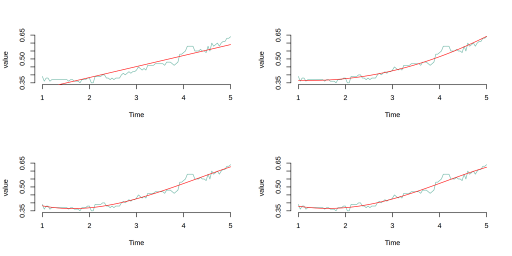

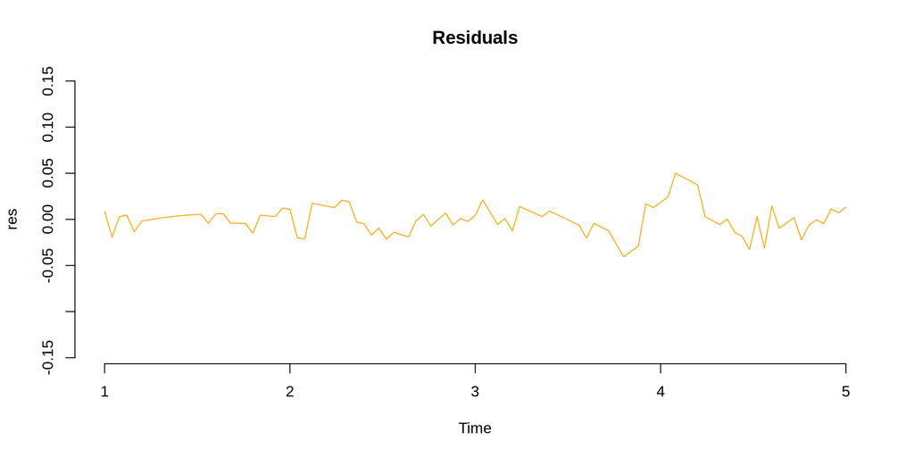

Based on the provided results, the polynomial of degree 3 seems to strike a good balance between model complexity and goodness of fit, as it has a relatively high adjusted R-squared and lower AIC/BIC compared to higher-degree polynomials.

#### Box-Jenkins method

##### Stagnation check

```
##
##  Augmented Dickey-Fuller Test
##
## data:  value_ts
## Dickey-Fuller = -1.9222, Lag order = 4, p-value = 0.6089
## alternative hypothesis: stationary
```

The ADF test suggests non-stationarity, but it doesn’t provide strong evidence.

```
##
##  KPSS Test for Level Stationarity
##
## data:  value_ts
## KPSS Level = 1.9715, Truncation lag parameter = 4, p-value = 0.01
```

The KPSS test suggests non-stationarity and provides stronger evidence against stationarity.

##### Differences transformation

We apply the difference transformation until the Augmented Dickey-Fuller Test (adf) gives (p-value<0.05)

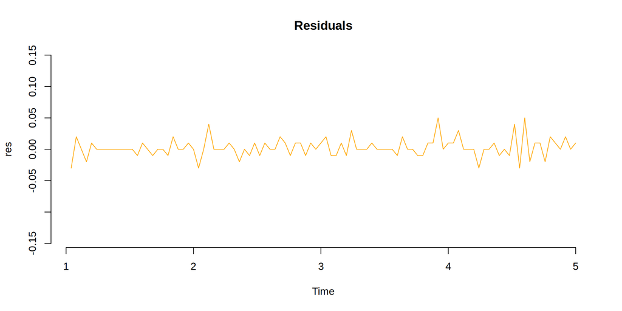

##### Autocorrelation - heteroscedasticity

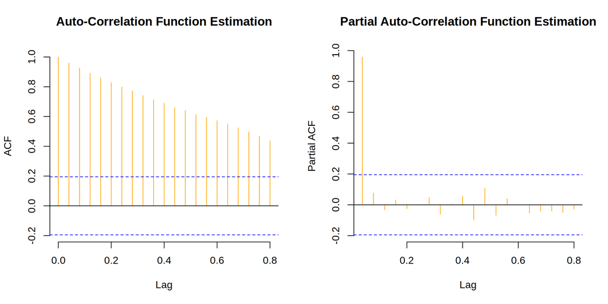

##### Auto-regressive model (AR(p))

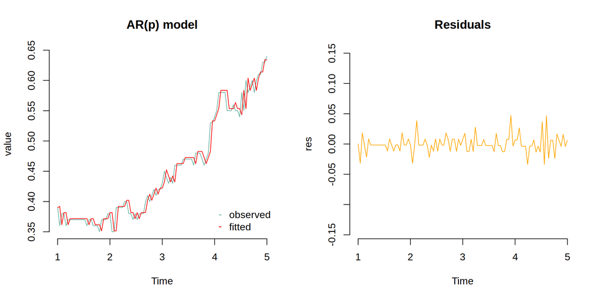

##### Moving Average model (MA(q))

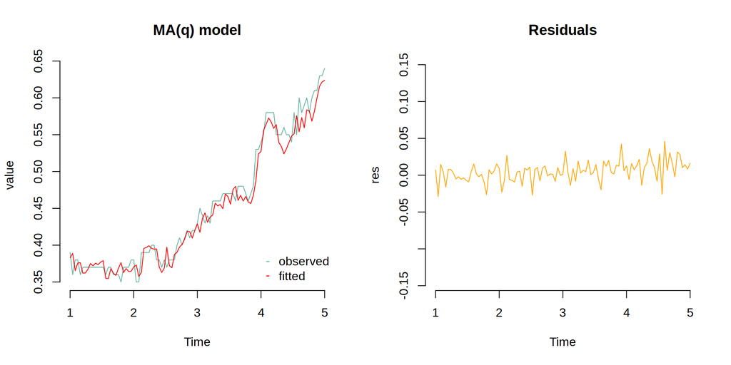